# 16S rRNA amplicon sequencing QC

Author

Laura Symul

Published

March 9, 2026

**Note**

This document only perform minimal QC at the moment - a lot of the upstream QC has been performed by Joseph Elsherbini and Johnathan Shih in Kwon’s lab and Asavela Kama at CAPRISA (Ngcapu’s lab).

The main purpose of this document is to summarize the counts and relative abundances at the species level, and to harmonize and prepare the data so that it can be integrated with other assays for downstream analyses.

```r
library(tidyverse)
library(magrittr)
library(gt)
library(patchwork)
library(Matrix)
library(SummarizedExperiment)
library(tidySummarizedExperiment)
library(phyloseq) # devtools::install_github("joey711/phyloseq")
#BiocManager::install("mia")
# library(mia)



# tmp <- fs::dir_map("R scripts mg/", source)
tmp <- fs::dir_map("R scripts/", source)
tmp <- fs::dir_map("../VIBRANT-99-utils/R", source)
rm(tmp)

theme_set(theme_light())
```

## Loading the data

The data is provided as a `phyloseq` object in an `.rds` file.

```r
ps <-
  readRDS(str_c(get_data_dir(),"04 16S rRNA sequencing/raw_merged_all_pools_ps_20250523.rds"))

ps
```

```
phyloseq-class experiment-level object
otu_table()   OTU Table:         [ 283061 taxa and 4377 samples ]
sample_data() Sample Data:       [ 4377 samples by 28 sample variables ]
tax_table()   Taxonomy Table:    [ 283061 taxa by 7 taxonomic ranks ]
```

Sample data:

```r
ps@sam_data |>
  as.data.frame() |>
  as_tibble() |>
  glimpse()
```

```
Rows: 4,377
```

```
Columns: 28
$ sampleID                                  <chr> "2152449_068200035_0000", "2…
$ Sample.ID.Barcode                         <chr> "2152449", "2154015", "21540…
$ Patient.ID                                <chr> "68200035", "68200040", "682…
$ Visit.code                                <chr> "0", "0", "1200", "1000", "1…
$ IDT.adapter.name                          <chr> "IDT10_UDI_Adapter2", "IDT10…
$ i5.index.forward                          <chr> "CGTAGAACAG", "ACCTAAGAGC", …
$ i5.index.reverse                          <chr> "CTGTTCTACG", "GCTCTTAGGT", …
$ i7.index.reverse                          <chr> "ATAAGCGGAG", "CGACCTTAAT", …
$ i7.index                                  <chr> "CTCCGCTTAT", "ATTAAGGTCG", …
$ sample_id                                 <chr> "2152449_068200035_0000", "2…
$ spike_in_Allobacillus_halotolerans_rel    <dbl> 0, 0, 0, 0, 0, 0, 0, 0, 0, 0…
$ spike_in_Imtechella_halotolerans_rel      <dbl> 0, 0, 0, 0, 0, 0, 0, 0, 0, 0…
$ spike_in_Allobacillus_halotolerans_counts <dbl> 0, 0, 0, 0, 0, 0, 0, 0, 0, 0…
$ spike_in_Imtechella_halotolerans_counts   <dbl> 0, 0, 0, 0, 0, 0, 0, 0, 0, 0…
$ total_spike_in_rel                        <dbl> 0, 0, 0, 0, 0, 0, 0, 0, 0, 0…
$ total_spike_in_counts                     <dbl> 0, 0, 0, 0, 0, 0, 0, 0, 0, 0…
$ CST                                       <chr> "III", "IV-B", "IV-B", "IV-B…
$ subCST                                    <chr> "III-B", "IV-B", "IV-B", "IV…
$ score                                     <dbl> 0.9200522, 0.6396295, 0.7183…
$ Specimen.type                             <chr> "Vaginal Swab", "Vaginal Swa…
$ Well.ID                                   <chr> "B01", "C01", "D01", "E01", …
$ pool                                      <chr> "pool1", "pool1", "pool1", "…
$ Volume.pooled..uL.                        <dbl> 3, 3, 3, 3, 3, 3, 3, 3, 3, 3…
$ Researcher                                <chr> "Jiawu", "Jiawu", "Jiawu", "…
$ Description                               <chr> "VIBRANT", "VIBRANT", "VIBRA…
$ Pool10                                    <chr> NA, NA, NA, NA, NA, NA, NA, …
$ Original.MGH.aliquot.Unique.identifier    <dbl> NA, NA, NA, NA, NA, NA, NA, …
$ Site                                      <chr> NA, NA, NA, NA, NA, NA, NA, …
```

Taxonomic table:

```r
ps@tax_table |> as.data.frame() |> as_tibble() |> glimpse()
```

```
Rows: 283,061
Columns: 7
$ Domain  <chr> "d_Bacteria", "d_Bacteria", "d_Bacteria", "d_Bacteria", "d_Bac…
$ Phylum  <chr> "p_Bacillota", "p_Bacillota_A", "p_Bacillota", "p_Bacillota", …
$ Class   <chr> "c_Bacilli", "c_Clostridia", "c_Bacilli", "c_Bacilli", "c_Cori…
$ Order   <chr> "o_Lactobacillales", "o_Lachnospirales", "o_Lactobacillales", …
$ Family  <chr> "f_Lactobacillaceae", "f_Lachnospiraceae", "f_Lactobacillaceae…
$ Genus   <chr> "g_Lactobacillus", "g_UBA629", "g_Lactobacillus", "g_Lactobaci…
$ Species <chr> "Lactobacillus_crispatus", "Ca_Lachnocurva_vaginae", "Lactobac…
```

## Data cleaning, documentation, and harmonization of the identifying variables

### Dimensions and sparsity

The `phyloseq` object contains counts for 4377 samples and 283061 ASVs.

```r
counts <- ps@otu_table |> as.matrix()
prop_0 <- mean(counts == 0)
```

```r
props <- counts/rowSums(counts)
```

```r
class(counts) <- "matrix"
class(props) <- "matrix"
```

This is a very large number of ASVs (probably because `dada2` denoises for sequencing errors but not amplification errors) and most of them are not present in most samples as the proportion of 0s in the count table is 99.93%.

```r
ASV_stats <-
  tibble(
    ASV_nb = 1:ncol(counts),
    total_counts = colSums(counts),
    mean_counts = colMeans(counts),
    n_non_zero = colSums(counts > 0),
    f_non_zero = n_non_zero / nrow(counts),
    max_counts = colMaxs(counts),
    mean_rel_ab = colMeans(props),
    max_rel_ab = colMaxs(props)
  )
```

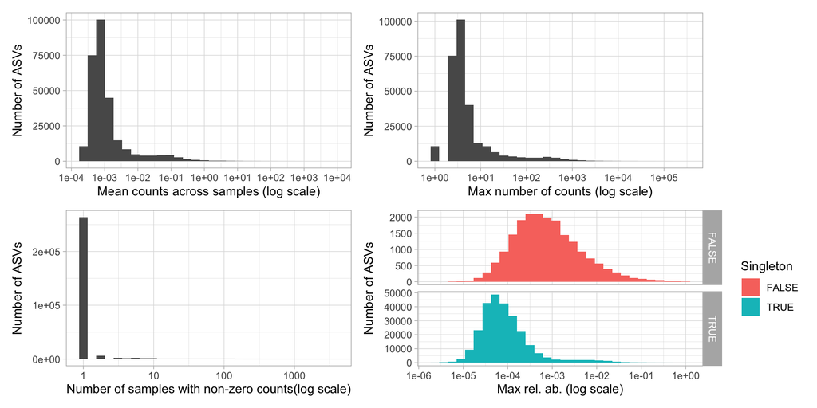

```r
ASV_stats |> ggplot() + aes(x = mean_counts) + geom_histogram(bins = 30) +
  scale_x_log10(n.breaks = 10) +
  labs(x = "Mean counts across samples (log scale)", y = "Number of ASVs") +


ASV_stats |> ggplot() + aes(x = max_counts) + geom_histogram(bins = 30) +
    scale_x_log10(n.breaks = 8) +
  labs(x = "Max number of counts (log scale)", y = "Number of ASVs") +

ASV_stats |> ggplot() + aes(x = n_non_zero) + geom_histogram(bins = 30) +
    scale_x_log10(n.breaks = 6) +
  labs(x = "Number of samples with non-zero counts(log scale)", y = "Number of ASVs") +


ASV_stats |> ggplot() + aes(x = max_rel_ab, fill = n_non_zero == 1) +
  facet_grid(n_non_zero == 1 ~ ., scales = "free") +
  geom_histogram(bins = 30) +
  scale_x_log10(n.breaks = 8) +
  labs(x = "Max rel. ab. (log scale)", y = "Number of ASVs", fill = "Singleton") +

  plot_layout(nrow = 2)
```

93.1% of ASVs (n = 263543) are present (non-zero counts) in only 1 sample.

```r
ASV_stats |>
  mutate(`ASV category` = ifelse(n_non_zero == 1, "ASVs with counts in only 1 sample (singletons)", "ASVs with counts in >1 sample")) |>
  group_by(`ASV category`) |>
  summarize(
    `n ASVs` = n(),
    `cummulative reads` = sum(total_counts),
    `highest rel. ab.` = max(max_rel_ab),
    `average highest rel. ab.` = mean(max_rel_ab) |> round(5)
    ) |>
  mutate(
    `% ASV` = round(`n ASVs` / sum(`n ASVs`) * 100, 2),
    `proportion of total reads` = round(`cummulative reads` / sum(`cummulative reads`) * 100, 2)
    ) |>
  relocate(`% ASV`, .after = `n ASVs`) |>
  relocate(`proportion of total reads`, .after = `cummulative reads`) |>
  gt()
```

| ASV category | n ASVs | % ASV | cummulative reads | proportion of total reads | highest rel. ab. | average highest rel. ab. |
| --- | --- | --- | --- | --- | --- | --- |
| ASVs with counts in >1 sample | 19518 | 6.9 | 212633574 | 97.02 | 1 | 0.00626 |
| ASVs with counts in only 1 sample (singletons) | 263543 | 93.1 | 6525875 | 2.98 | 1 | 0.00070 |

While, collectively, these ASVs (singletons) account for less than 3% of all counts, a few singletons make up a substantial proportion of the sample they are found in (up to 100% of the reads in a few samples).

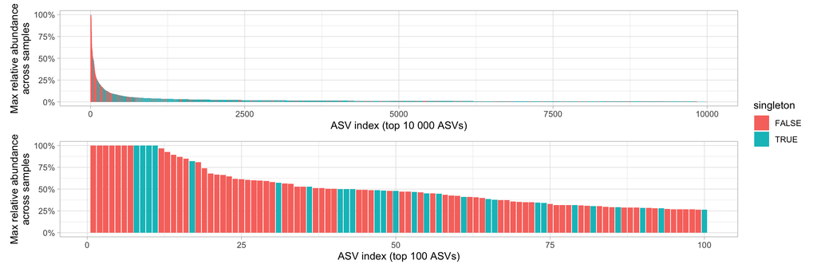

```r
ASV_stats <-
  ASV_stats |>
  arrange(-max_rel_ab) |>
  mutate(i = row_number(), singleton = (n_non_zero == 1))

ASV_stats |>
  filter(i <= 10000) |>
  ggplot() +
  aes(x = i, y = max_rel_ab, fill = singleton) +
  geom_col() +
  scale_x_continuous("ASV index (top 10 000 ASVs)") +
  scale_y_continuous("Max relative abundance\nacross samples", labels = scales::label_percent(accuracy = 1)) +

ASV_stats |>
  filter(i <= 100) |>
  ggplot() +
  aes(x = i, y = max_rel_ab, fill = singleton) +
  geom_col() +
  scale_x_continuous("ASV index (top 100 ASVs)") +
  scale_y_continuous("Max relative abundance\nacross samples", labels = scales::label_percent(accuracy = 1)) +

  plot_layout(nrow = 2, guides = "collect")
```

```r
singletons_to_check <- ASV_stats |> filter(singleton, max_rel_ab > 0.5)
```

```r
samples_to_check <- props[, singletons_to_check$ASV_nb] |> rowSums()
samples_to_check <- samples_to_check[samples_to_check > 0]
```

```r
props_to_check <- props[names(samples_to_check),]
props_to_check_long <-
  props_to_check |>
  as.data.frame() |>
  rownames_to_column("sample_id") |>
  pivot_longer(-sample_id, names_to = "ASV_seq", values_to = "rel_ab") |>
  filter(rel_ab > 0) |>
  dplyr::left_join(
    ps@tax_table |>
      as.data.frame() |>
      as_tibble(rownames = "ASV_seq") |>
      mutate(ASV_nb = row_number()),
    by = join_by(ASV_seq)
  )
```

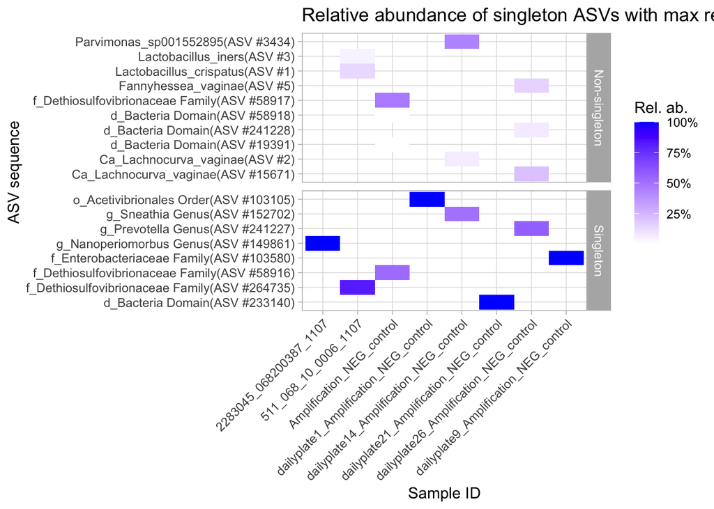

```r
props_to_check_long |>
  mutate(singleton =  ifelse(ASV_nb %in% singletons_to_check$ASV_nb, "Singleton", "Non-singleton")) |>
  ggplot() +
  aes(x = sample_id, y = str_c(Species, "(ASV #", ASV_nb, ")") , fill = rel_ab) +
  facet_grid(singleton ~ ., scales = "free", space = "free") +
  geom_tile() +
  scale_fill_gradient(low = "white", high = "blue", labels = scales::label_percent(accuracy = 1)) +
  theme(
    axis.text.x = element_text(angle = 90, hjust = 1, vjust = 0.5)
  ) +
  labs(x = "Sample ID", y = "ASV sequence", fill = "Rel. ab.") +
  ggtitle("Relative abundance of singleton ASVs with max rel. ab. > 0.5") +
  theme(
    axis.text.x = element_text(angle = 45, hjust = 1, vjust = 1)
  )
```

Many of these “high relative abundances singletons” are in negative controls.

```r
# tmp <-
#   ps@tax_table |>
#   as.data.frame()
#
# j <-  which(tmp$Species == "Lactobacillus_crispatus")
#
# tmp <- counts[,j]
# tmp <- tmp |> as.data.frame()
#
# tmp_long <-
#   tmp |>
#   set_colnames(1:ncol(tmp)) |>
#   rownames_to_column("sample_id") |>
#   pivot_longer(-sample_id, names_to = "L_crisp_ASV_nb", values_to = "counts")
#
# tmp_long |>
#   ggplot() +
#   aes(x = sample_id, y = L_crisp_ASV_nb, fill = counts |> asinh()) +
#   geom_tile() +
#   scale_fill_gradient(low = "white", high = "blue")
```

```r
rm(counts, ASV_stats, singletons_to_check, samples_to_check, props_to_check, props_to_check_long)
```

### Creation a of `SummarizedExperiment` object

To facilitate data harmonization and cleaning, we transform the `phyloseq` object to a `SummarizedExperiment` object.

We first create a `SummarizedExperiment` object at the ASV resolution which we will then aggregate at the smallest taxonomic level below, after cleaning and harmonization of the identifying variables.

```r
make_se_from_ps <- function(ps) {

  # ROWDATA (Tax table)
  se_rowdata <-
    ps@tax_table |>
    as.data.frame() |>
    rownames_to_column("ASV_sequence") |>
    mutate(ASV_order = row_number()) |>
    group_by(Species) |>
    mutate(ASV_id = str_c(Species, " (ASV", ASV_order |> str_pad(width = 6, pad = "0"),")")) |>
    ungroup() |>
    mutate(rownames = ASV_id) |>
    column_to_rownames("rownames") |>
    relocate(ASV_sequence, .after = ASV_id)  |>
    janitor::clean_names()

  # we do some cleaning of the names and variables
  se_rowdata <-
    se_rowdata |>
    mutate(
      domain = domain |> str_remove("^d_"),
      phylum = phylum |> str_remove("^[dp]_") |>
        str_replace(" Domain", " (Domain)"),
      class = class |> str_remove("^[dpc]_") |>
        str_replace(" Domain", " (Domain)"),
      order = order |> str_remove("^[dpco]_") |>
        str_replace(" Domain", " (Domain)") |>
        str_replace(" Class", " (Class)"),
      family = family |> str_remove("^[dpcof]_") |>
        str_replace(" Domain", " (Domain)") |>
        str_replace(" Class", " (Class)") |>
        str_replace(" Order", " (Order)"),
      genus = genus |> str_remove("^[dpcofg]_") |>
        str_replace(" Domain", " (Domain)") |>
        str_replace(" Class", " (Class)") |>
        str_replace(" Order", " (Order)") |>
        str_replace(" Family", " (Family)"),
      species = species |> str_remove("^[dpcofg]_") |>
        str_replace(" Domain", " (Domain)") |>
        str_replace(" Class", " (Class)") |>
        str_replace(" Order", " (Order)") |>
        str_replace(" Family", " (Family)") |>
        str_replace(" Genus", " (Genus)") |>
        str_replace_all("_", " "),
      last_available_taxonomic_level =
        species |>
        str_extract("\\(Domain\\)|\\(Class\\)|\\(Order\\)|\\(Family\\)|\\(Genus\\)") |>
        str_remove("\\(") |> str_remove("\\)") |>
        str_replace_na("Species"),
      asv_label = asv_id |> str_replace_all("_", " ")
    ) |>
    select(asv_id, everything(), asv_label)


  rowData_dictionary <-
    tibble(name = colnames(se_rowdata)) |>
    dplyr::full_join(
      tibble(original_name = ps@tax_table |> colnames()) |>
        mutate(name = original_name |> str_to_lower()),
      by = join_by(name)
    ) |>
    mutate(
      description =
      case_when(
        name == "asv_id" ~ "Unique ASV identifier",
        name == "asv_label" ~ "ASV label (for pretty printing)",
        name == "domain" ~ "Domain",
        name == "phylum" ~ "Phylum",
        name == "class" ~ "Class",
        name == "order" ~ "Order",
        name == "family" ~ "Family",
        name == "genus" ~ "Genus",
        name == "species" ~ "Species",
        name == "asv_order" ~ "ASV order as provided in the original `phyloseq` object",
        name == "asv_sequence" ~ "ASV sequence",
        name == "last_available_taxonomic_level" ~ "Last available taxonomic level for the ASV",
        TRUE ~ "???"
      )
    )


  # COLDATA (Sample data)
  se_coldata <-
    ps@sam_data |>
    as.data.frame() |>
    as_tibble() |>  # weird trick because of the sticky `phyloseq` attribute
    as.data.frame() |>
    set_rownames(rownames(ps@sam_data))

  colData_dictionary <-
    tibble(
      original_name = se_coldata |> colnames()
    )

  se_coldata <- se_coldata |> janitor::clean_names()
  se_coldata <- se_coldata |> dplyr::rename(visit_code_ps = visit_code)

  colData_dictionary <- colData_dictionary |> bind_cols(name = colnames(se_coldata))

  se_coldata <- se_coldata |> mutate(sample_id_ps = rownames(se_coldata))


  # ASSSAY
  raw_counts <- ps@otu_table |> as.matrix()
  class(raw_counts) <- "matrix"
  raw_counts <- Matrix::Matrix(raw_counts, sparse = TRUE)
  raw_counts <- raw_counts |> t()
  rownames(raw_counts) <- se_rowdata$asv_id

  # SummarizedExperiment

  se <-
    SummarizedExperiment(
      assays = list(
        counts = raw_counts,
        rel_ab = t(t(raw_counts) / colSums(raw_counts))
      ),
      rowData = se_rowdata,
      colData = se_coldata,
      metadata = list(
        name = "VIBRANT 16S rRNA amplicon sequencing (ASV-level)",
        date = today(),
        dictionary =
          bind_rows(
            colData_dictionary |> mutate(table = "colData"),
            rowData_dictionary |> mutate(table = "rowData")
          )
      )
    )


  se
}
```

```r
se_16S_ASV <- make_se_from_ps(ps)
se_16S_ASV_backup <- se_16S_ASV
```

```r
se_16S_ASV
```

```
class: SummarizedExperiment
dim: 283061 4377
metadata(3): name date dictionary
assays(2): counts rel_ab
rownames(283061): Lactobacillus_crispatus (ASV000001)
  Ca_Lachnocurva_vaginae (ASV000002) ... Peptoniphilus_sp900343085
  (ASV283060) Lactobacillus_iners (ASV283061)
rowData names(12): asv_id domain ... last_available_taxonomic_level
  asv_label
colnames(4377): 2152449_068200035_0000 2154015_068200040_0000 ...
  subsampled_2291276_068200415_1300 subsampled_2291282_068200398_1400
colData names(29): sample_id sample_id_barcode ... site sample_id_ps
```

We renamed the columns in the sample data:

```r
se_16S_ASV@metadata$dictionary |> gt()
```

| original_name | name | table | description |
| --- | --- | --- | --- |
| sampleID | sample_id | colData | NA |
| Sample.ID.Barcode | sample_id_barcode | colData | NA |
| Patient.ID | patient_id | colData | NA |
| Visit.code | visit_code_ps | colData | NA |
| IDT.adapter.name | idt_adapter_name | colData | NA |
| i5.index.forward | i5_index_forward | colData | NA |
| i5.index.reverse | i5_index_reverse | colData | NA |
| i7.index.reverse | i7_index_reverse | colData | NA |
| i7.index | i7_index | colData | NA |
| sample_id | sample_id_2 | colData | NA |
| spike_in_Allobacillus_halotolerans_rel | spike_in_allobacillus_halotolerans_rel | colData | NA |
| spike_in_Imtechella_halotolerans_rel | spike_in_imtechella_halotolerans_rel | colData | NA |
| spike_in_Allobacillus_halotolerans_counts | spike_in_allobacillus_halotolerans_counts | colData | NA |
| spike_in_Imtechella_halotolerans_counts | spike_in_imtechella_halotolerans_counts | colData | NA |
| total_spike_in_rel | total_spike_in_rel | colData | NA |
| total_spike_in_counts | total_spike_in_counts | colData | NA |
| CST | cst | colData | NA |
| subCST | sub_cst | colData | NA |
| score | score | colData | NA |
| Specimen.type | specimen_type | colData | NA |
| Well.ID | well_id | colData | NA |
| pool | pool | colData | NA |
| Volume.pooled..uL. | volume_pooled_u_l | colData | NA |
| Researcher | researcher | colData | NA |
| Description | description | colData | NA |
| Pool10 | pool10 | colData | NA |
| Original.MGH.aliquot.Unique.identifier | original_mgh_aliquot_unique_identifier | colData | NA |
| Site | site | colData | NA |
| NA | asv_id | rowData | Unique ASV identifier |
| Domain | domain | rowData | Domain |
| Phylum | phylum | rowData | Phylum |
| Class | class | rowData | Class |
| Order | order | rowData | Order |
| Family | family | rowData | Family |
| Genus | genus | rowData | Genus |
| Species | species | rowData | Species |
| NA | asv_order | rowData | ASV order as provided in the original `phyloseq` object |
| NA | asv_sequence | rowData | ASV sequence |
| NA | last_available_taxonomic_level | rowData | Last available taxonomic level for the ASV |
| NA | asv_label | rowData | ASV label (for pretty printing) |

### Harmonization of sample and participant IDs

We have data for the following samples:

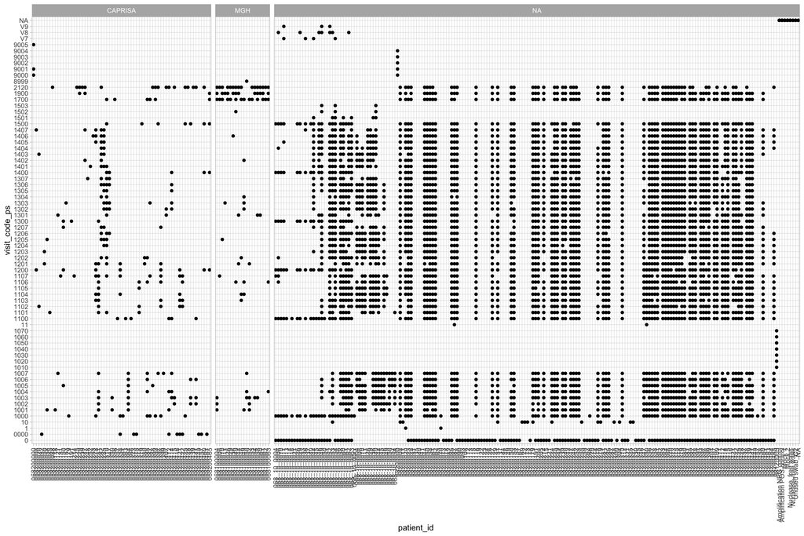

```r
se_16S_ASV@colData |>
  as.data.frame() |>
  ggplot() +
  aes(x = patient_id, y = visit_code_ps) +
  geom_point() +
  facet_grid(. ~ site, scales = "free", space = "free") +
  theme(
    axis.text.x = element_text(angle = 90, hjust = 1, vjust = 0.5)
  )
```

We see that we’ll have to harmonize the `patient_id` and `visit_code` columns. From harmonized participant ID, we’ll be able to impute the site location.

```r
se_16S_ASV@colData <-
  se_16S_ASV@colData |>
  as.data.frame() |>
  mutate(
    pid =
      patient_id |>
      str_remove_all("_") |>
      str_remove_all("-") |>
      str_replace_all("^68","068")
  ) |>
  DataFrame()
```

```r
se_16S_ASV@colData |>
  as.data.frame() |>
  mutate(pid_length = str_length(pid)) |>
  dplyr::filter(pid_length != 9) |>
  dplyr::count(patient_id, pid) |>
  gt(
    caption = "Samples with non-standard participant IDs"
  )
```

Samples with non-standard participant IDs

| patient_id | pid | n |
| --- | --- | --- |
| 98120009 | 98120009 | 7 |
| Amplification NEG control | Amplification NEG control | 27 |
| Amplification POS control | Amplification POS control | 42 |
| Mock 1 | Mock 1 | 44 |
| Mock 2 | Mock 2 | 46 |
| Nuclease-free water | Nucleasefree water | 5 |
| Nuclease_free water | Nucleasefree water | 29 |
| Unused swab_C2 | Unused swabC2 | 34 |

**Note**

As in the metagenomics, there were 7 samples from a participant from another study (starting by (0)98).

The rest looks legit.

We next clean the `visit_code_ps` and define the `visit_code` column

```r
se_16S_ASV@colData |>
  as.data.frame() |>
  dplyr::count(visit_code_ps)
```

```r
se_16S_ASV@colData <-
  se_16S_ASV@colData |>
  as.data.frame() |>
  mutate(
    visit_code =
      visit_code_ps |>
      str_replace("V7", "1700") |>
      str_replace("V8", "1900") |>
      str_replace("V9", "2120") |>
      str_pad(width = 4, pad = "0")
  ) |>
  DataFrame()
```

We also create new columns for the `sample_type` and `control_type`

```r
se_16S_ASV@colData <-
  se_16S_ASV@colData |>
  as.data.frame() |>
  mutate(
    sample_type =
      case_when(
        str_detect(pid, "^068") ~ "Clinical sample",
        str_detect(pid, "98") ~ "Clinical sample (other study)",
        str_detect(pid, "Amplification NEG control") | str_detect(sample_id, "Amplification_NEG_control") ~ "Amplification negative control",
        str_detect(pid, "Amplification POS control") | str_detect(sample_id, "Amplification_POS_control") ~ "Amplification positive control",
        str_detect(pid, "Mock") | str_detect(sample_id, "Mock") ~ "Positive control",
        str_detect(pid, "water") | str_detect(pid, "Unused") | str_detect(sample_id, "water") | str_detect(sample_id, "Unused")  ~ "Negative control",
      ),
    control_type =
      case_when(
        str_detect(sample_type, "Clinical") ~ "",
        str_detect(sample_id, "Mock1") ~ "Mock 1",
        str_detect(pid, "Mock") ~ pid,
        str_detect(pid, "water") | str_detect(sample_id, "water") ~ "Nuclease-free water",
        str_detect(pid, "Unused") | str_detect(sample_id, "Unused")  ~ "Unused swab + C2",
        TRUE ~ sample_type
      )
  ) |>
  DataFrame()
```

```r
se_16S_ASV@colData |>
  as.data.frame() |>
  dplyr::count(sample_type, control_type) |>
  gt()
```

| sample_type | control_type | n |
| --- | --- | --- |
| Amplification negative control | Amplification negative control | 29 |
| Amplification positive control | Amplification positive control | 47 |
| Clinical sample |  | 4133 |
| Clinical sample (other study) |  | 7 |
| Negative control | Nuclease-free water | 35 |
| Negative control | Unused swab + C2 | 35 |
| Positive control | Mock 1 | 45 |
| Positive control | Mock 2 | 46 |

```r
se_16S_ASV$pid <-
  ifelse(
    !(se_16S_ASV$sample_type %in% c("Clinical sample", "Clinical sample (other study)")),
    NA_character_,
    se_16S_ASV$pid
    )
```

We also create two columns (`ext_lib_plate_type` and `ext_lib_plate_nb`) that contains information about the extraction library plate (from Sinaye) so that we’ll be able to compare the controls between 16S and metagenomics (the barcodes do not seem to match those provided by Michael - there, in the metagenomics data, the biological controls barcode start with “EQ”)

**Note**

Does that “EQ”-starting barcodes sound familiar or not at all?

```r
tmp <-
  se_16S_ASV@colData |>
  as_tibble() |>
  dplyr::filter(sample_type %in% c("Positive control", "Negative control")) |>
  select(sample_id, sample_type, control_type) |>
  mutate(
    ext_lib_plate_type =
      case_when(
        str_detect(sample_id, "^dailyplate") ~ "CAP daily swabs",
        str_detect(sample_id, "^mghdailyplate") ~ "MGH daily swabs",
        str_detect(sample_id, "^plate") ~ "Weekly swabs",
        str_detect(sample_id, "_plate1") ~ "Weekly swabs",
        TRUE ~ "???"
      ),
    ext_lib_plate_nb = sample_id |> str_remove("Mock1_") |> parse_number()
  )
```

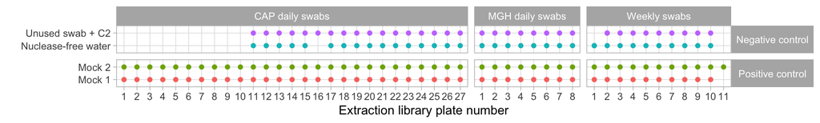

```r
tmp |>
  ggplot() +
  aes(x = ext_lib_plate_nb |> factor(), y = control_type, col = control_type) +
  facet_grid(sample_type ~ ext_lib_plate_type, scales = "free", space = "free") +
  geom_point() +
  xlab("Extraction library plate number") +
  ylab("") +
  guides(col = "none") +
  theme(strip.text.y = element_text(angle = 0))
```

```r
tmp <-
  se_16S_ASV@colData |>
  as.data.frame() |>
  select(sample_id) |>
  dplyr::left_join(tmp |> select(sample_id, starts_with("ext_lib_plate")), by = "sample_id")

se_16S_ASV@colData$ext_lib_plate_type <- tmp$ext_lib_plate_type
se_16S_ASV@colData$ext_lib_plate_nb <- tmp$ext_lib_plate_nb
```

### Number of observation per `pid` and `visit_code`

After harmonizing the `pid` and `visit_code`, we notice that a number of participants have two samples per visit.

All of these “replicates” are from “pool10” which was composed of samples that had to be re-sequenced.

```r
replicates <-
  se_16S_ASV@colData |>
  as.data.frame() |>
  as_tibble() |>
  dplyr::filter(sample_type == "Clinical sample")

replicates |>
  dplyr::count(pid, visit_code, name = "n samples per participant x visit") |>
  dplyr::count(`n samples per participant x visit`, name = "occurence") |>
  gt()
```

| n samples per participant x visit | occurence |
| --- | --- |
| 1 | 3797 |
| 2 | 168 |

```r
# se_16S_ASV@colData |>
#   as.data.frame() |>
#   as_tibble() |>
#   dplyr::filter(sample_type == "Clinical sample") |>
#   dplyr::count(patient_id, visit_code_ps) |>
#   dplyr::count(n)


replicates <-
  replicates |>
  group_by(pid, visit_code) |>
  arrange(visit_code) |>
  mutate(n = n(), rep_nb = row_number()) |>
  ungroup() |>
  dplyr::filter(n > 1) |>
  select(sample_id, patient_id, pid, visit_code_ps, visit_code, rep_nb, pool) |>
  arrange(pid, visit_code_ps)

replicates |>
  dplyr::count(rep_nb, pool) |>
  gt()
```

| rep_nb | pool | n |
| --- | --- | --- |
| 1 | pool1 | 29 |
| 1 | pool2 | 26 |
| 1 | pool3 | 2 |
| 1 | pool5 | 73 |
| 1 | pool6 | 19 |
| 1 | pool7 | 3 |
| 1 | pool8 | 14 |
| 1 | pool9 | 2 |
| 2 | pool10 | 168 |

We’ll do a comparison of the composition of these samples below.

```r
se_16S_ASV@colData$resequenced <- "No"
se_16S_ASV@colData$resequenced[se_16S_ASV@colData$sample_id %in% replicates$sample_id[replicates$pool != "pool10"]] <- "Yes"
se_16S_ASV@colData$resequenced[se_16S_ASV@colData$sample_id %in% replicates$sample_id[replicates$pool == "pool10"]] <- "2nd sequencing"

se_16S_ASV@colData$resequenced <-
  se_16S_ASV@colData$resequenced |>
  factor(levels = c("No", "Yes", "2nd sequencing"))
```

### Matching `pid` and `visit_code` with the CRF data

**Note**

Below, I load a list of all visits for all participants as found in the CRF data - this is **NOT** based on CRF-based specimen collection data (CRF35 or CRF47). That comparison will be done after the `MultiAssayExperiment` object is built.

> TODO: change the path and file this loads after finalization of clinical data cleaning.

```r
load("/Users/laurasymul/OneDrive - UCL/Academia/Research/VIBRANT clinical data UCLouvain/Data processed/2025-05-14/visits_summary.RData", verbose = TRUE)
```

```
Loading objects:
  v
```

```r
v <- v |> dplyr::rename(visit_code_crf = visit_code) |> mutate(pid = str_c("068", pid))
```

```r
v <-
  v |>
  mutate(visit_code = visit_code_crf |> as.character() |> str_pad(width = 4, pad = "0"))
```

```r
v |>
  ggplot() +
  aes(x = pid, y = visit_code, col = randomized) +
  geom_point() +
  facet_grid(. ~ location + randomized, scales = "free", space = "free") +
  theme(
    axis.text.x = element_text(angle = 90, hjust = 1, vjust = 0.5)
  ) +
  ggtitle("CRF data")
```

[output not shown]

```r
matched <-
  dplyr::full_join(
    se_16S_ASV@colData |>
      as.data.frame() |>
      dplyr::filter(sample_type == "Clinical sample") |>
      as_tibble() |>
      select(pid, visit_code, patient_id, visit_code_ps, sample_id, site) |>
      mutate(has_16S_data = TRUE),
    v |> select(pid, visit_code) |>  mutate(has_CRF_data = TRUE),
    by = join_by(pid, visit_code)
  ) |>
  mutate(
    has_16S_data = has_16S_data |> replace_na(FALSE),
    has_CRF_data = has_CRF_data |> replace_na(FALSE)
  ) |>
  dplyr::left_join(
    v |> select(pid, location, met_eligibility, randomized) |> distinct() |> mutate(pid_in_CRFs = TRUE),
    by = join_by(pid)
  ) |>
  mutate(
    pid_in_CRFs = pid_in_CRFs |> replace_na(FALSE)
  )
```

```r
matched |>
  dplyr::count(has_16S_data, has_CRF_data, pid_in_CRFs, randomized, name = "n entries") |>
  gt()
```

| has_16S_data | has_CRF_data | pid_in_CRFs | randomized | n entries |
| --- | --- | --- | --- | --- |
| FALSE | TRUE | TRUE | FALSE | 414 |
| FALSE | TRUE | TRUE | TRUE | 188 |
| TRUE | FALSE | FALSE | NA | 9 |
| TRUE | FALSE | TRUE | FALSE | 3 |
| TRUE | FALSE | TRUE | TRUE | 110 |
| TRUE | TRUE | TRUE | FALSE | 75 |
| TRUE | TRUE | TRUE | TRUE | 3936 |

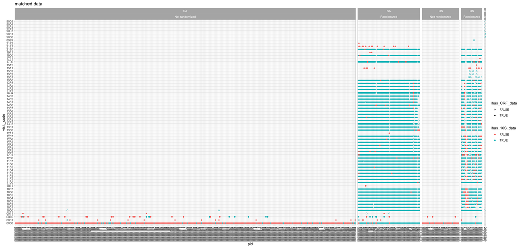

```r
matched |>
  ggplot() +
  aes(x = pid, y = visit_code, col = has_16S_data, shape = has_CRF_data) +
  geom_point() +
  facet_grid(. ~ location + ifelse(randomized,"Randomized", "Not randomized"), scales = "free", space = "free") +
  theme(
    axis.text.x = element_text(angle = 90, hjust = 1, vjust = 0.5)
  ) +
  scale_shape_manual(values = c(1, 16)) +
  ggtitle("matched data")
```

Let’s focus on

- “Clinical samples” in the 16S data that we do not have in the CRFs
- Randomized participants with non-matching visits in the 16S data.

#### Participant ID not in the CRFs

```r
matched |>
  dplyr::filter(is.na(location)) |>
  dplyr::count(pid, patient_id) |>
  gt()
```

| pid | patient_id | n |
| --- | --- | --- |
| 0681000xx | 068_10_00xx | 1 |
| 068200000 | 068200000 | 3 |
| 068200000 | 68200000 | 5 |

These are likely “test” participants.

We change their `sample_type` to “Test sample”.

```r
se_16S_ASV$sample_type <-
  ifelse(
    se_16S_ASV$pid %in% c("0681000xx", "068200000"),
    "Test sample",
    se_16S_ASV$sample_type
    )
```

#### Randomized participants with non-matching visits in the 16S data

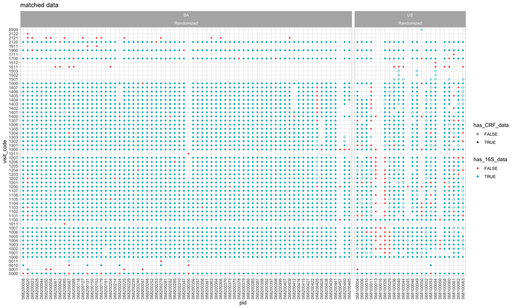

```r
matched |>
  dplyr::filter(randomized) |>
   ggplot() +
  aes(x = pid, y = visit_code, col = has_16S_data, shape = has_CRF_data) +
  geom_point(size = 1.5) +
  facet_grid(. ~ location + ifelse(randomized,"Randomized", "Not randomized"), scales = "free", space = "free") +
  theme(
    axis.text.x = element_text(angle = 90, hjust = 1, vjust = 0.5)
  ) +
  scale_shape_manual(values = c(1, 16)) +
  ggtitle("matched data")
```

We have a quite ok match. Some observations around the mismatches:

- We see a few examples of likely mis-labelled visits (*e.g.,* around the screening visits)
- and a few “missing” 16S at visits where swabs are not expected (*e.g.* 2121 or 1511).
- One SA participant has a whole week of missed swabs, but another week without crfs but with swabs.
- A few US participants were supposed to collect swabs but likely did not (to check with the “daily specimen collection CRF” (CRF47) after `MAE` creation)

Overall, it looks reasonable.

### Fixing `visit_code`

We fix a few `visit_code` based on the CRF data, trial information, or based on information provided by the different labs.

```r
se_16S_ASV@colData |>
  as_tibble() |>
  dplyr::filter(visit_code == "8999") |>
  select(sample_id, patient_id, pid, visit_code_ps, visit_code)


se_16S_ASV@colData |>
  as_tibble() |>
  dplyr::filter(visit_code == "0011") |>
  select(sample_id, patient_id, pid, visit_code_ps, visit_code)

se_16S_ASV@colData |>
  as_tibble() |>
  dplyr::filter(pid == "068200023") |>
  select(sample_id, patient_id, pid, visit_code_ps, visit_code)


matched |>
  dplyr::filter(randomized) |>
  dplyr::filter(has_16S_data, !has_CRF_data) |>
  arrange(pid, visit_code) |> View()
```

```r
se_16S_ASV@colData <-
  se_16S_ASV@colData |>
  as.data.frame() |>
  mutate(
    visit_code =
      case_when(
        # one MGH participant had their visit code set to the termination visit code.
        # However, for the other assays, it was the actual visit code that was used instead.
        # for that participant (068100050), their last visit was 1700
        (pid == "068100050") & (visit_code == "8999") ~ "1700",
        # two CAP participants had "0011" as their visit code.
        # these should be replaced by "0010"
        (visit_code == "0011") ~ "0010",
        TRUE ~ visit_code
      )
  ) |>
  DataFrame()
```

### Defining VIBRANT `uid`

```r
se_16S_ASV$uid <-
  ifelse(
    !is.na(se_16S_ASV$pid),
    str_c(
      se_16S_ASV$pid, "_",
      se_16S_ASV$visit_code
    ),
    se_16S_ASV$sample_id
  )
```

Note that these `uid` are not unique because of the replicates from “pool10” (see above). There are 168 duplicated `uid` in the data.

### Adding library size (`total_counts`) to the `colData`

```r
se_16S_ASV@colData$total_counts <- colSums(assay(se_16S_ASV, "counts"))
```

### Re-ordering `colData` columns, removing empty columns, and completing the dictionary.

```r
# se_16S_ASV@colData |> colnames()

# (se_16S_ASV$sample_id == se_16S_ASV$sample_id_ps) |> all()
# (se_16S_ASV$sample_id == se_16S_ASV$sample_id_2) |> all()

se_16S_ASV$patient_id_ps <- se_16S_ASV$patient_id

empty_cols <- colData(se_16S_ASV) |> apply(2, function(x) {is.na(x) |> all()}) |> which() |> names()
if (length(empty_cols) > 0) {
  warning(str_c("The following columns in the colData are empty and will be removed: ", str_c(empty_cols, collapse = ", ")))
}
unique_values_cols <- (apply(colData(se_16S_ASV), 2, function(x) {unique(x) |> length()}) == 1) |> which() |> names()
if (length(unique_values_cols) > 0) {
  warning(str_c("The following columns in the colData have only one unique value and will be removed:\n\t", str_c(unique_values_cols, collapse = ",\n\t")))
}

cols_to_remove <-
  c("sample_id", "sample_id_2", "patient_id", empty_cols, unique_values_cols)

ordered_cols <-
  unique(
    c(
      "uid", "pid", "visit_code", "sample_type", "control_type", "site",
      "ext_lib_plate_type", "ext_lib_plate_nb",
      "total_counts", "resequenced",
      "sample_id_ps", "sample_id_barcode", "patient_id_ps", "visit_code_ps",
      "specimen_type", "description", "original_mgh_aliquot_unique_identifier",
      "pool", "pool10", "researcher", "well_id", "volume_pooled_u_l",
      colnames(colData(se_16S_ASV))
    )
  ) |>
  setdiff(cols_to_remove)

colData(se_16S_ASV) <- colData(se_16S_ASV)[,ordered_cols]
```

```r
se_16S_ASV@metadata$dictionary <-
  se_16S_ASV@metadata$dictionary |>
  mutate(
    name =
      case_when(
        name == "sample_id" ~ "sample_id_ps",
        name == "patient_id" ~ "patient_id_ps",
        TRUE ~ name
      ),
    description =
      case_when(
        original_name == "sampleID" ~ "Original sample ID from the 16S data phyloseq object",
        original_name == "Sample.ID.Barcode" ~ "Concatenation of the swab barcode and the sample ID from the 16S data phyloseq object",
        original_name == "Patient.ID" ~ "Patient ID as provided in the 16S data phyloseq object",
        original_name == "Visit.code" ~ "Visit code as provided in the 16S data phyloseq object",

        name == "uid" ~ "VIBRANT unique sample identifier",
        name == "pid" ~ "VIBRANT participant ID (NA for non-clinical samples)",
        name == "visit_code" ~ "VIBRANT visit code (NA for non-clinical samples)",
        name == "sample_type" ~ "Type of sample (clinical sample, positive control, negative control, etc.)",
        name == "control_type" ~ "Type of control (if applicable)",
        name == "site" ~ "Study site (CAP or MGH)",
        name == "ext_lib_plate_type" ~ "Type of extraction library plate",
        name == "ext_lib_plate_nb" ~ "Extraction library plate number",
        name == "total_counts" ~ "Total counts in the sample (library size)",
        name == "resequenced" ~ "Whether the sample was resequenced due to low read count or other issues",
        name == "cst" ~ "Community State Type as assigned by VALENCIA",
        name == "sub_cst" ~ "Community State Sub-Type as assigned by VALENCIA",
        name == "score" ~ "Sub-CST assignment score as estimated by VALENCIA",
        TRUE ~ description
      ),
    removed = ifelse(name %in% cols_to_remove, TRUE, FALSE)
  )
```

```r
se_16S_ASV@metadata$dictionary |> gt()
```

| original_name | name | table | description | removed |
| --- | --- | --- | --- | --- |
| sampleID | sample_id_ps | colData | Original sample ID from the 16S data phyloseq object | FALSE |
| Sample.ID.Barcode | sample_id_barcode | colData | Concatenation of the swab barcode and the sample ID from the 16S data phyloseq object | FALSE |
| Patient.ID | patient_id_ps | colData | Patient ID as provided in the 16S data phyloseq object | FALSE |
| Visit.code | visit_code_ps | colData | Visit code as provided in the 16S data phyloseq object | FALSE |
| IDT.adapter.name | idt_adapter_name | colData | NA | FALSE |
| i5.index.forward | i5_index_forward | colData | NA | FALSE |
| i5.index.reverse | i5_index_reverse | colData | NA | FALSE |
| i7.index.reverse | i7_index_reverse | colData | NA | FALSE |
| i7.index | i7_index | colData | NA | FALSE |
| sample_id | sample_id_2 | colData | NA | TRUE |
| spike_in_Allobacillus_halotolerans_rel | spike_in_allobacillus_halotolerans_rel | colData | NA | TRUE |
| spike_in_Imtechella_halotolerans_rel | spike_in_imtechella_halotolerans_rel | colData | NA | TRUE |
| spike_in_Allobacillus_halotolerans_counts | spike_in_allobacillus_halotolerans_counts | colData | NA | TRUE |
| spike_in_Imtechella_halotolerans_counts | spike_in_imtechella_halotolerans_counts | colData | NA | TRUE |
| total_spike_in_rel | total_spike_in_rel | colData | NA | TRUE |
| total_spike_in_counts | total_spike_in_counts | colData | NA | TRUE |
| CST | cst | colData | Community State Type as assigned by VALENCIA | FALSE |
| subCST | sub_cst | colData | Community State Sub-Type as assigned by VALENCIA | FALSE |
| score | score | colData | Sub-CST assignment score as estimated by VALENCIA | FALSE |
| Specimen.type | specimen_type | colData | NA | FALSE |
| Well.ID | well_id | colData | NA | FALSE |
| pool | pool | colData | NA | FALSE |
| Volume.pooled..uL. | volume_pooled_u_l | colData | NA | FALSE |
| Researcher | researcher | colData | NA | FALSE |
| Description | description | colData | NA | FALSE |
| Pool10 | pool10 | colData | NA | FALSE |
| Original.MGH.aliquot.Unique.identifier | original_mgh_aliquot_unique_identifier | colData | NA | FALSE |
| Site | site | colData | Study site (CAP or MGH) | FALSE |
| NA | asv_id | rowData | Unique ASV identifier | FALSE |
| Domain | domain | rowData | Domain | FALSE |
| Phylum | phylum | rowData | Phylum | FALSE |
| Class | class | rowData | Class | FALSE |
| Order | order | rowData | Order | FALSE |
| Family | family | rowData | Family | FALSE |
| Genus | genus | rowData | Genus | FALSE |
| Species | species | rowData | Species | FALSE |
| NA | asv_order | rowData | ASV order as provided in the original `phyloseq` object | FALSE |
| NA | asv_sequence | rowData | ASV sequence | FALSE |
| NA | last_available_taxonomic_level | rowData | Last available taxonomic level for the ASV | FALSE |
| NA | asv_label | rowData | ASV label (for pretty printing) | FALSE |

### Renaming `SE` samples

```r
tmp <-
  tibble(
    uid = se_16S_ASV$uid,
    total_counts = se_16S_ASV$total_counts
  ) |>
  mutate(i = row_number()) |>
  group_by(uid) |>
  arrange(uid, -total_counts) |>
  mutate(
    n = n(),
    new_colnames = str_c(uid, ifelse((n > 1) & (row_number() > 1), str_c("_r", row_number()), ""))
  ) |>
  ungroup() |>
  arrange(i)

colnames(se_16S_ASV) <- tmp$new_colnames

rm(tmp)
```

## Aggregation at the smallest taxonomic level

As noted above, the raw `phyloseq` object contained 283061 ASVs, which is a lot more than the expected true biological diversity, and as described above, many of these ASVs are singletons and likely spurious.

Consequently, it may be useful to either further denoise the data or to aggregate the data at a higher taxonomic level.

Here, for simplicity, we aggregate the data at the species level.

```r
# Note, for the aggregation, one natural choice would be to use the `phyloseq::tax_glom()` function.
# However, here, that function throws an error
# (LS thinks it doesn't work because of the large number of ASVs... but didn't dig very deep)
ps_agg <- ps |> tax_glom("Species")

# Further, since we've already performed some cleaning when moving from a phyloseq to a SummarizedExperiment object, it is easier to aggregate ourselves from the SummarizedExperiment object instead of going back to the phyloseq object.
```

```r
aggregate_se <- function(se, agg_var = "aggregating_variable", assays){

  # this is helpful for the aggregation of the rowData variables (see below) in case of disagreement between the different variables (e.g., taxonomic variables) when there are several values per agg_var
  no_dominant_feature <- TRUE
  if (!any("dominant_feature" %in% colnames(rowData(se)))) {
    rowData(se)$dominant_feature <- FALSE
  } else {
    no_dominant_feature <- FALSE
  }

  #
  if (!any("taxon_id" %in% colnames(rowData(se)))) {
    warning("No `taxon_id` variable in the rowData. A `taxon_id` variable will be created with the same values as the `agg_var` variable.")
    rowData(se)$taxon_id <- NA_character_
  }
  if (!any("taxon_label" %in% colnames(rowData(se)))) {
    warning("No `taxon_label` variable in the rowData. A `taxon_label` variable will be created with the same values as the `agg_var` variable.")
    rowData(se)$taxon_label <- NA_character_
  }

  aggregated_row_data <-
    rowData(se) |>
    as.data.frame() |>
    mutate(new_feature = !!sym(agg_var)) |>
    mutate(i = row_number()) |>
    group_by(new_feature) |>
    summarize(
      across(
        -any_of(c("i", "n_asv")),
        ~ if(length(unique(.x)) == 1) {
          unique(.x)
        } else if(any(dominant_feature)) {
          .x[dominant_feature] |> unique() |> extract(1)
        } else {
          NA
        }
      ),
      n_aggregated_features = n(),
      i = min(i),
      across(any_of("n_asv"), sum),
      .groups = "drop"
    ) |>
    mutate(
      taxon_id =
        case_when(
          is.na(taxon_id) ~ new_feature,
          TRUE ~ taxon_id
        ),
      taxon_label =
        case_when(
          is.na(taxon_label) ~ new_feature |> str_replace_all("_", " ") |> str_to_sentence() |> str_c(" (aggregated)"),
          TRUE ~ taxon_label
        )
    ) |>
    arrange(i) |>
    select(-i) |>
    as.data.frame() |>
    column_to_rownames("new_feature")

  if (no_dominant_feature) {
    aggregated_row_data <- aggregated_row_data |> select(-dominant_feature)
  }

  j <- apply(aggregated_row_data, 2, function(x) all(is.na(x))) |> which()
  if (length(j) > 0) {
    warning(str_c("The following variables in the rowData are all NA after aggregation and will be removed: ", str_c(colnames(aggregated_row_data)[j], collapse = ", ")))
    aggregated_row_data <- aggregated_row_data |> select(-all_of(colnames(aggregated_row_data)[j]))
  }

  aggregated_row_data <-
    aggregated_row_data |>
    select(taxon_id, taxon_label, domain:species, last_available_taxonomic_level, n_aggregated_features, everything())


  aggregated_assay_list <-
    map(
      assays,
      .f = aggregate_assay,
      se = se,
      agg_var = agg_var,
      new_features = rownames(aggregated_row_data)
    ) |>
    set_names(assays)


  original_rowData <- rowData(se)
  original_rowData[, "agg_var"] <- original_rowData[, agg_var]

  SummarizedExperiment::SummarizedExperiment(
    assays = aggregated_assay_list,
    rowData = aggregated_row_data,
    colData = colData(se),
    metadata =
      list(
        "note" = str_c("original SummarizedExperiment aggregated by ", agg_var),
        original_rowData = original_rowData
        ) |>
      c(metadata(se))
  )

}

aggregate_assay <- function(assay_name, se, agg_var, new_features){
  assay(se, assay_name) |>
    base::rowsum(group = rowData(se)[,agg_var]) |>
    magrittr::extract(new_features, rownames(colData(se)))
}
```

```r
se_16S_species <-
  aggregate_se(
    se_16S_ASV, agg_var = "species", assays = c("counts", "rel_ab")
    )
```

```r
se_16S <- se_16S_species
```

## Exploratory & QC analyses

### Distribution of counts and relative abundances per taxon

```r
taxon_summary <-
  se_16S |>
  as_tibble() |>
  group_by(.feature) |>
  summarize(
    n_samples = n(),
    n_non_zero_samples = sum(counts > 0, na.rm = TRUE),
    mean_rel_ab = (mean(rel_ab, na.rm = TRUE) * 100) |> round(2),
    max_rel_ab = (max(rel_ab, na.rm = TRUE) * 100) |> round(2),
    sd_rel_ab = (sd(rel_ab, na.rm = TRUE) * 100) |> round(2),
    pc_10 = (quantile(rel_ab, 0.1, na.rm = TRUE) * 100) |> round(2),
    pc_50 = (quantile(rel_ab, 0.5, na.rm = TRUE) * 100) |> round(2),
    pc_90 = (quantile(rel_ab, 0.9, na.rm = TRUE) * 100) |> round(2)
  )
```

```r
taxon_summary |>
  arrange(-n_non_zero_samples) |>
  slice_head(n = 20) |>
  select(.feature, n_samples, n_non_zero_samples, mean_rel_ab, max_rel_ab, pc_10, pc_50, pc_90) |>
  gt() |>
  cols_label(
    .feature = "taxon",
    n_samples = "N samples",
    n_non_zero_samples = "n samples with non-zero counts",
    mean_rel_ab = "Average relative abundance across samples (%)",
    max_rel_ab = "Maximum relative abundance across samples (%)",
    pc_10 = "10th percentile relative abundance across samples (%)",
    pc_50 = "Median relative abundance across samples (%)",
    pc_90 = "90th percentile relative abundance across samples (%)"
  )
```

| taxon | N samples | n samples with non-zero counts | Average relative abundance across samples (%) | Maximum relative abundance across samples (%) | 10th percentile relative abundance across samples (%) | Median relative abundance across samples (%) | 90th percentile relative abundance across samples (%) |
| --- | --- | --- | --- | --- | --- | --- | --- |
| Bacteria (Domain) | 4377 | 4000 | 1.74 | 100.00 | 0.01 | 0.49 | 4.08 |
| Gardnerella vaginalis | 4377 | 3944 | 9.73 | 100.00 | 0.00 | 5.54 | 25.89 |
| Lactobacillus iners | 4377 | 3856 | 24.97 | 100.00 | 0.00 | 9.20 | 79.60 |
| Lactobacillus (Genus) | 4377 | 3698 | 1.40 | 17.34 | 0.00 | 0.54 | 4.17 |
| Nanoperiomorbus (Genus) | 4377 | 3495 | 0.64 | 100.00 | 0.00 | 0.09 | 1.42 |
| Dethiosulfovibrionaceae (Family) | 4377 | 3206 | 1.96 | 100.00 | 0.00 | 0.10 | 5.15 |
| Fannyhessea vaginae | 4377 | 3191 | 3.60 | 73.26 | 0.00 | 0.39 | 11.19 |
| Dialister (Genus) | 4377 | 3188 | 0.32 | 8.95 | 0.00 | 0.12 | 0.85 |
| Prevotella (Genus) | 4377 | 3105 | 1.66 | 62.50 | 0.00 | 0.07 | 3.74 |
| Bifidobacteriaceae (Family) | 4377 | 3047 | 0.14 | 7.58 | 0.00 | 0.03 | 0.36 |
| Sneathia (Genus) | 4377 | 2897 | 1.01 | 50.07 | 0.00 | 0.08 | 3.52 |
| Sneathia vaginalis | 4377 | 2849 | 4.94 | 62.92 | 0.00 | 0.10 | 18.80 |
| Prevotella timonensis | 4377 | 2808 | 1.33 | 53.44 | 0.00 | 0.06 | 3.51 |
| Dialister micraerophilus | 4377 | 2745 | 0.11 | 18.03 | 0.00 | 0.03 | 0.27 |
| Aerococcus christensenii | 4377 | 2559 | 1.16 | 54.00 | 0.00 | 0.02 | 1.28 |
| Sneathia sanguinegens | 4377 | 2534 | 2.62 | 51.69 | 0.00 | 0.04 | 9.02 |
| Berryella sp001552935 | 4377 | 2521 | 0.82 | 20.51 | 0.00 | 0.03 | 2.76 |
| Peptoniphilug A (Genus) | 4377 | 2440 | 0.08 | 1.62 | 0.00 | 0.01 | 0.26 |
| Finegoldia magna H | 4377 | 2431 | 0.47 | 29.27 | 0.00 | 0.01 | 0.80 |
| Lactobacillus crispatus | 4377 | 2411 | 17.41 | 100.00 | 0.00 | 0.01 | 79.87 |

### Total number of counts per sample.

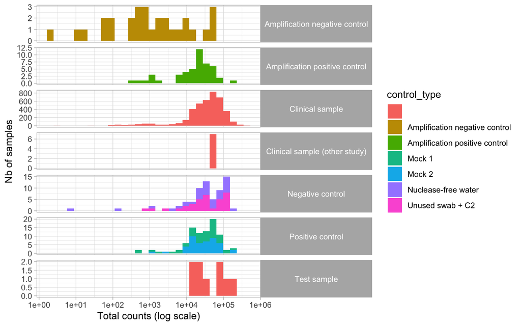

```r
se_16S@colData |>
  as.data.frame() |>
  ggplot() +
  aes(x = total_counts, fill = control_type) +
  geom_histogram(bins = 30) +
  scale_x_log10(n.breaks = 8) +
  labs(x = "Total counts (log scale)", y = "Nb of samples") +
  facet_grid(sample_type ~ ., scales = "free") +
  theme(strip.text.y = element_text(angle = 0))
```

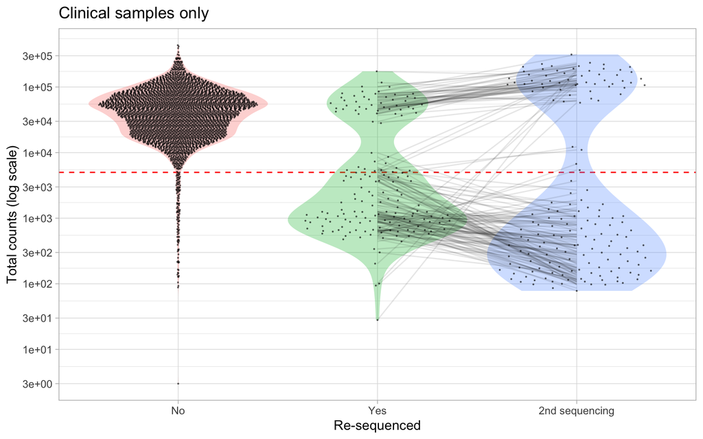

```r
se_16S@colData |>
  as.data.frame() |>
  dplyr::filter(sample_type == "Clinical sample") |>
  ggplot() +
  aes(x = resequenced, y = total_counts, fill = resequenced) +
  # geom_histogram(bins = 30) +
  geom_hline( yintercept = 5000, col = "red", linetype = "dashed") +
  geom_violin(alpha = 0.3, col = "transparent", scale = "width") +
  ggbeeswarm::geom_quasirandom(alpha = 0.5, size = 0.1) +
  geom_path(aes(group = interaction(pid, visit_code)), alpha = 0.1) +
  scale_y_log10(n.breaks = 8) +
  guides(fill = "none") +
  labs(x = "Re-sequenced", y = "Total counts (log scale)") +
  ggtitle("Clinical samples only")
```

We recommend excluding samples with less than 5000 counts for downstream analyses.

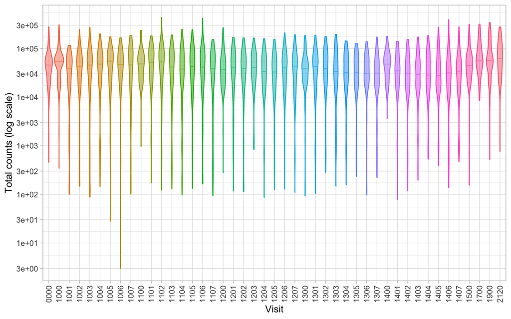

```r
tmp <-
  se_16S@colData |>
  as.data.frame() |>
  dplyr::filter(!is.na(visit_code)) |>
  group_by(visit_code) |> mutate(n = n()) |> ungroup() |>
  dplyr::filter(n > 20) |>
  mutate(visit_code = visit_code |> factor()) |>
  arrange(pid, visit_code)

tmp |>
  ggplot() +
  aes(y = total_counts, x = visit_code, fill = visit_code, col = visit_code) +
  # geom_path(aes(group = pid), alpha = 0.15) +
  geom_violin(draw_quantiles = 0.5, alpha = 0.5) + # fill = "gray",
  scale_y_log10(n.breaks = 10) +
  guides(fill = "none", col = "none") +
  labs(y = "Total counts (log scale)", x = "Visit") +
  theme(axis.text.x = element_text(angle = 90, vjust = 0.5))
```

### Controls

#### Amplification negative controls

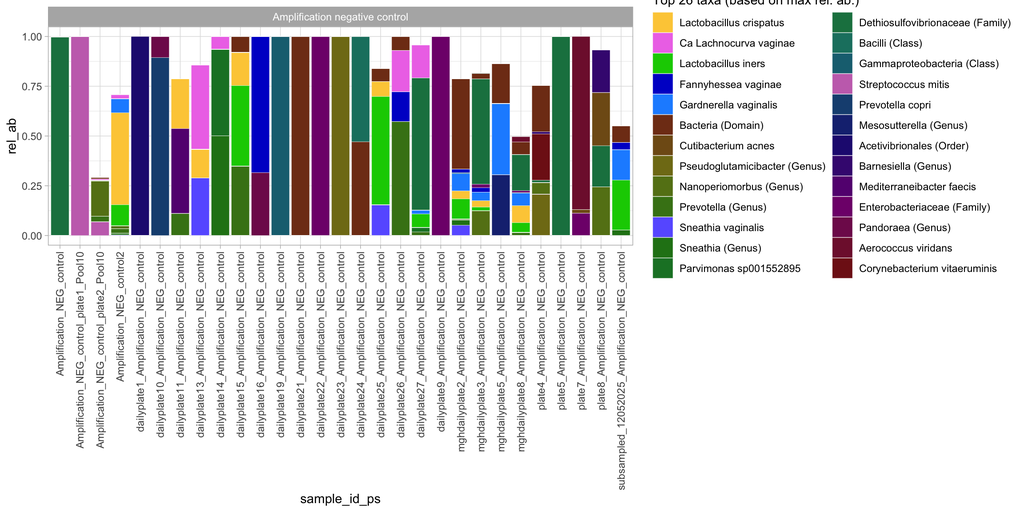

```r
tmp <-
  se_16S |>
  dplyr::filter(sample_type == "Amplification negative control") |>
  as_tibble() |>
  group_by(.feature) |>
  mutate(max_rel_ab = max(rel_ab)) |>
  ungroup() |>
  dplyr::filter(max_rel_ab > 0.2)

tmp |>
  ggplot() +
  aes(x = sample_id_ps, y = rel_ab, fill = .feature) +
  geom_col(col = "white", linewidth = 0.1) +
  scale_fill_manual(
    str_c("Top ", tmp$.feature |> unique() |> length(), " taxa (based on max rel. ab.)"),
    breaks = tmp$.feature |> unique(),
    values = tmp$.feature |> unique() |> get_taxa_colors()
  ) +
  facet_grid(. ~ control_type, scales = "free_x", space = "free_x") +
  theme(
    strip.text.y = element_text(angle = 0),
    axis.text.x = element_text(angle = 90, hjust = 1, vjust = 0.5)
    )
```

#### Amplification positive controls

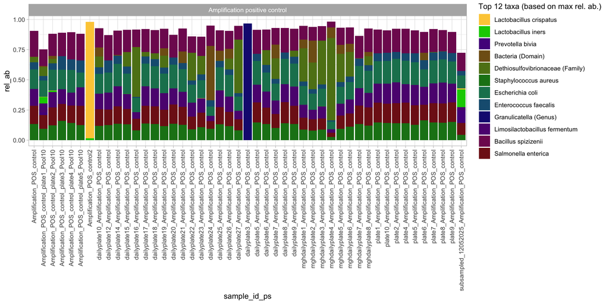

```r
tmp <-
  se_16S |>
  dplyr::filter(sample_type == "Amplification positive control") |>
  as_tibble() |>
  group_by(.feature) |>
  mutate(max_rel_ab = max(rel_ab)) |>
  ungroup() |>
  dplyr::filter(max_rel_ab > 0.1)

tmp |>
  ggplot() +
  aes(x = sample_id_ps, y = rel_ab, fill = .feature) +
  geom_col() +
  scale_fill_manual(
    str_c("Top ", tmp$.feature |> unique() |> length(), " taxa (based on max rel. ab.)"),
    breaks = tmp$.feature |> unique(),
    values = tmp$.feature |> unique() |> get_taxa_colors()
  ) +
  facet_grid(. ~ control_type, scales = "free_x", space = "free_x") +
  theme(
    strip.text.y = element_text(angle = 0),
    axis.text.x = element_text(angle = 90, hjust = 1, vjust = 0.5)
    )
```

**Note**

Anyone from the labs that can explain this outlier? And/or if it’s important?

#### Negative controls

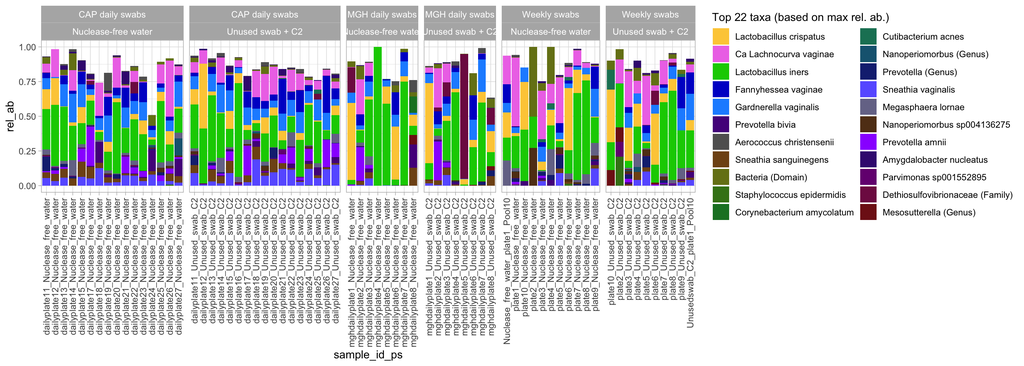

```r
tmp <-
  se_16S |>
  dplyr::filter(sample_type == "Negative control") |>
  as_tibble() |>
  group_by(.feature) |>
  mutate(max_rel_ab = max(rel_ab)) |>
  ungroup() |>
  dplyr::filter(max_rel_ab > 0.1)

tmp |>
  ggplot() +
  aes(x = sample_id_ps, y = rel_ab, fill = .feature) +
  geom_col() +
  scale_fill_manual(
    str_c("Top ", tmp$.feature |> unique() |> length(), " taxa (based on max rel. ab.)"),
    breaks = tmp$.feature |> unique(),
    values = tmp$.feature |> unique() |> get_taxa_colors()
  ) +
  facet_grid(. ~ ext_lib_plate_type + control_type, scales = "free_x", space = "free_x") +
  theme(
    strip.text.y = element_text(angle = 0),
    axis.text.x = element_text(angle = 90, hjust = 1, vjust = 0.5)
    )
```

#### Positive controls

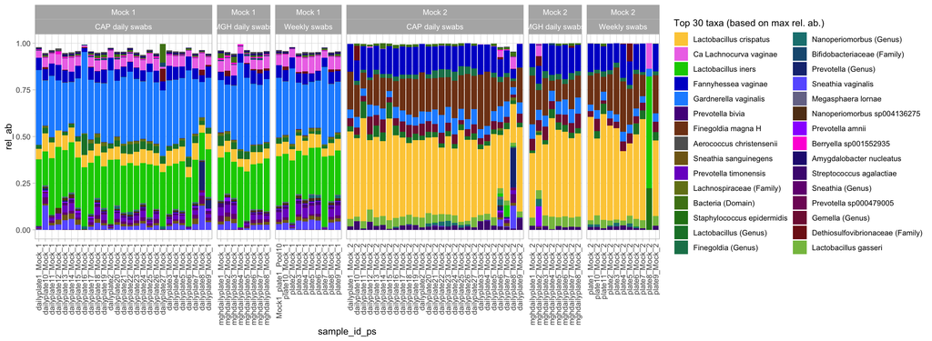

```r
tmp <-
  se_16S |>
  dplyr::filter(sample_type == "Positive control") |>
  as_tibble() |>
  group_by(.feature) |>
  mutate(max_rel_ab = max(rel_ab)) |>
  ungroup() |>
  dplyr::filter(max_rel_ab > 0.01)

tmp |>
  ggplot() +
  aes(x = sample_id_ps, y = rel_ab, fill = .feature) +
  geom_col() +
  scale_fill_manual(
    str_c("Top ", tmp$.feature |> unique() |> length(), " taxa (based on max rel. ab.)"),
    breaks = tmp$.feature |> unique(),
    values = tmp$.feature |> unique() |> get_taxa_colors()
  ) +
  facet_grid(. ~ control_type + ext_lib_plate_type, scales = "free_x", space = "free_x") +
  theme(
    strip.text.y = element_text(angle = 0),
    axis.text.x = element_text(angle = 90, hjust = 1, vjust = 0.5)
    )
```

That gives us an idea of the replicability and expected variability in the 16S data.

### Replicates

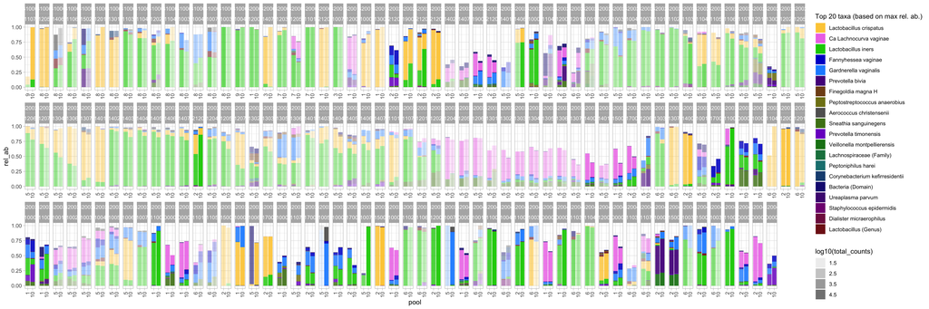

```r
tmp <-
  se_16S |>
  as_tibble() |>
  dplyr::filter(sample_type == "Clinical sample") |>
  group_by(pid, visit_code) |>
  mutate(n = sample_id_ps |> unique() |> length()) |>
  ungroup() |>
  dplyr::filter(n > 1) |>
  dplyr::filter(.feature %in% .feature[1:20])
  # group_by(.feature) |>
  # mutate(max_rel_ab = max(rel_ab)) |>
  # ungroup() |>
  # dplyr::filter(max_rel_ab > 0.1)

tmp |>
  ggplot() +
  aes(x = pool |> parse_number() |> factor(), y = rel_ab,
      fill = .feature, alpha = total_counts |> log10()) +
  geom_col() +
  scale_fill_manual(
    str_c("Top ", tmp$.feature |> unique() |> length(), " taxa (based on max rel. ab.)"),
    breaks = tmp$.feature |> unique(),
    values = tmp$.feature |> unique() |> get_taxa_colors()
  ) +
  facet_wrap(. ~ pid + visit_code, scales = "free_x", nrow = 3) +
  theme(
    strip.text.y = element_text(angle = 0),
    axis.text.x = element_text(angle = 90, hjust = 1, vjust = 0.5)
    ) +
  xlab("pool")
```

Relatively good agreement between the replicates; for the longitudinal profiles below, when we have replicates, we’ll use the replicate that had the most total reads.

## Longitudinal profiles for randomized participants

```r
tmp <-
  se_16S@colData |>
  as.data.frame() |>
  select(-any_of(c("randomized", "location"))) |>
  dplyr::left_join(
    v |> select(pid, randomized, location) |> distinct(),
    by = join_by(pid)
  )

se_16S@colData$randomized <- tmp$randomized
se_16S@colData$location <- tmp$location
```

```r
n_taxa <- 20

tmp <-
  se_16S |>
  dplyr::filter(randomized) |>
  as_tibble() |>
  dplyr::filter(.feature %in% .feature[1:n_taxa])

selected_replicates <-
  tmp |>
  select(sample_id_ps, pid, visit_code, pool, total_counts) |>
  distinct() |>
  arrange(pid, visit_code, -total_counts) |>
  group_by(pid, visit_code) |>
  slice_head(n = 1) |>
  ungroup() |>
  group_by(visit_code) |> mutate(n = n()) |> ungroup() |>
  dplyr::filter(n > 20)
```

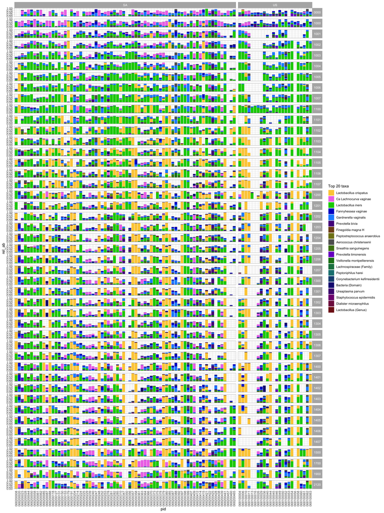

```r
tmp |>
  dplyr::filter(sample_id_ps %in% selected_replicates$sample_id_ps) |>
  ggplot() +
  aes(x = pid, y = rel_ab, fill = .feature) +
  geom_col() +
  scale_fill_manual(
    str_c("Top ", n_taxa, " taxa"),
    breaks = tmp$.feature |> unique(),
    values = tmp$.feature |> unique() |> get_taxa_colors()
  ) +
  facet_grid(visit_code ~ location, scales = "free_x", space = "free_x") +
  theme(
    strip.text.y = element_text(angle = 0),
    axis.text.x = element_text(angle = 90, hjust = 1, vjust = 0.5)
    )
```

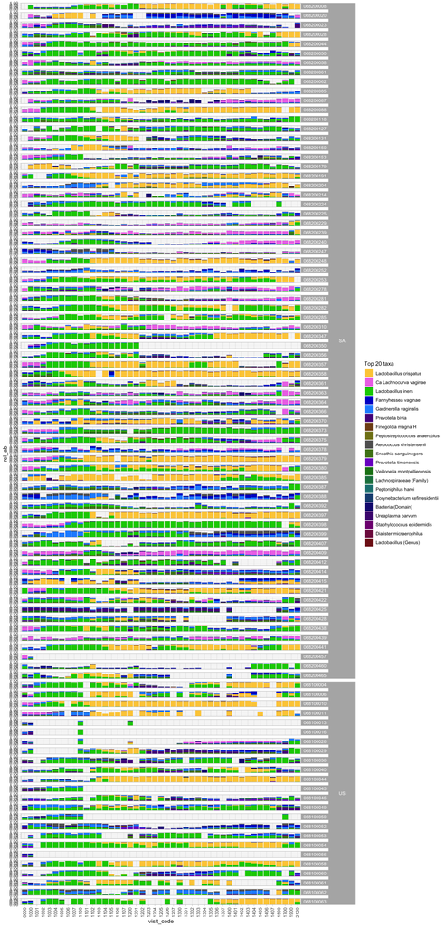

```r
tmp |>
  dplyr::filter(sample_id_ps %in% selected_replicates$sample_id_ps) |>
  ggplot() +
  aes(x = visit_code, y = rel_ab, fill = .feature) +
  geom_col() +
  scale_fill_manual(
    str_c("Top ", n_taxa, " taxa"),
    breaks = tmp$.feature |> unique(),
    values = tmp$.feature |> unique() |> get_taxa_colors()
  ) +
  ggh4x::facet_nested(location + pid ~ ., scales = "free_x", space = "free_x") +
  theme(
    strip.text.y = element_text(angle = 0),
    axis.text.x = element_text(angle = 90, hjust = 1, vjust = 0.5)
    )
```

## Save `SummarizedExperiment` objects

We save two pairs of `SE` objects to disk:

- `se_16S_ASV_all`: contains the counts and relative abundances at the ASV level for all the samples (including all the controls and replicates)
- `se_16S_ASV`: contains the counts and relative abundances at the ASV level for only the clinical samples (if replicates, we keep the one with the most total counts) and the positive and negative controls (but not the amplification controls).

and

- `se_16S_agg_all` and `se_16S_agg` who follow the same logic but for the aggregated data at the species level.

Before we do that, we flag the samples that may need to be excluded because of low total reads

```r
se_16S_ASV$exclude_sample <-
  ifelse(se_16S_ASV$total_counts < 5000, "Yes, low counts", "No")
se_16S$exclude_sample <-
  ifelse(se_16S$total_counts < 5000, "Yes, low counts", "No")

# we re-order the colData columns
ordered_cols <-
  unique(c("uid", "exclude_sample", colnames(colData(se_16S_ASV))))
colData(se_16S_ASV) <- colData(se_16S_ASV)[,ordered_cols]

ordered_cols <-
  unique(c("uid", "exclude_sample", colnames(colData(se_16S))))
colData(se_16S) <- colData(se_16S)[,ordered_cols]
```

Below, we identify the samples we want to keep for downstream analyses of the VIBRANT trial

```r
selected_sample_types <-
  c("Clinical sample", "Positive control", "Negative control")

selected_samples <-
  se_16S_ASV@colData |>
  as.data.frame() |>
  as_tibble() |>
  group_by(uid) |>
  arrange(uid, -total_counts) |>
  mutate(top_reads_replicate = (row_number() == 1)) |>
  ungroup() |>
  dplyr::filter(
    top_reads_replicate,
    sample_type %in% selected_sample_types
    ) |>
  select(uid) |>
  distinct()

if (selected_samples$uid |> str_detect("_r") |> any()) {
  warning("There are still some duplicated samples in the selected samples. Please check the `selected_samples` object.")
}
```

And define the `se_16S_ASV` and `se_16S_agg` objects that we will save to disk and integrate into the `MAE`

```r
se_16S_ASV_all <- se_16S_ASV
se_16S_ASV <- se_16S_ASV_all[ , selected_samples$uid]

se_16S_agg_all <- se_16S
se_16S_agg <- se_16S_agg_all[ , selected_samples$uid]
```

```r
se_16S_ASV
```

```
class: SummarizedExperiment
dim: 283061 4119
metadata(3): name date dictionary
assays(2): counts rel_ab
rownames(283061): Lactobacillus_crispatus (ASV000001)
  Ca_Lachnocurva_vaginae (ASV000002) ... Peptoniphilus_sp900343085
  (ASV283060) Lactobacillus_iners (ASV283061)
rowData names(12): asv_id domain ... last_available_taxonomic_level
  asv_label
colnames(4119): 068100004_0000 068100004_1000 ...
  plate9_Nuclease_free_water plate9_Unused_swab_C2
colData names(31): uid exclude_sample ... sub_cst score
```

```r
se_16S_agg
```

```
class: SummarizedExperiment
dim: 817 4119
metadata(5): note original_rowData name date dictionary
assays(2): counts rel_ab
rownames(817): Lactobacillus crispatus Ca Lachnocurva vaginae ...
  Tannerella forsythia Pauljensenia sp000758755
rowData names(15): taxon_id taxon_label ... asv_sequence asv_label
colnames(4119): 068100004_0000 068100004_1000 ...
  plate9_Nuclease_free_water plate9_Unused_swab_C2
colData names(33): uid exclude_sample ... randomized location
```

Finally, before saving the `se_16S_ASV` and `se_16S_agg` objects, we check that they are compatible with the requirements for integration into the `MAE`

```r
colData_columns <-
  colnames(colData(se_16S_ASV)) |>
  setdiff(c("pid", "visit_code", "site", "location"))
colData(se_16S_ASV) <- colData(se_16S_ASV)[, colData_columns]


colData_columns <-
  colnames(colData(se_16S_agg)) |>
  setdiff(c("pid", "visit_code", "site", "location"))
colData(se_16S_agg) <- colData(se_16S_agg)[, colData_columns]
```

```r
se_16S_ASV <- check_se(se_16S_ASV)
se_16S_agg <- check_se(se_16S_agg)
```

```r
saveRDS(
  se_16S_ASV_all,
  str_c(
    get_01_output_dir(),
    "04_se_16S_ASV_all_", today() |> str_remove_all("-"), ".rds"
    )
  )


saveRDS(
  se_16S_ASV,
  str_c(
    get_01_output_dir(),
    "04_se_16S_ASV_", today() |> str_remove_all("-"), ".rds"
    )
  )

saveRDS(
  se_16S_agg_all,
  str_c(
    get_01_output_dir(),
    "04_se_16S_agg_all_", today() |> str_remove_all("-"), ".rds"
    )
  )


saveRDS(
  se_16S_agg,
  str_c(
    get_01_output_dir(),
    "04_se_16S_agg_", today() |> str_remove_all("-"), ".rds"
    )
  )
```